# Risk Factor Analysis

## Outcome Variable

**Outcome Variable:** ever_swasted

## Predictor Variables

**Intervention Variable:** mage

**Adjustment Set:**

- arm
- meducyrs
- feducyrs
- W_mhtcm
- single
- delta_meducyrs
- delta_feducyrs
- delta_W_mhtcm
- delta_single

## Stratifying Variables

The analysis was stratified on these variable(s):

- agecat
- studyid
- country

## Data Summary

| agecat | studyid | country | mage | ever_swasted | n_cell | n |
| --- | --- | --- | --- | --- | --- | --- |
| 0-24 months | ki0047075b-MAL-ED | BANGLADESH | [20-30) | 0 | 167 | 263 |
| 0-24 months | ki0047075b-MAL-ED | BANGLADESH | [20-30) | 1 | 13 | 263 |
| 0-24 months | ki0047075b-MAL-ED | BANGLADESH | <20 | 0 | 32 | 263 |
| 0-24 months | ki0047075b-MAL-ED | BANGLADESH | <20 | 1 | 5 | 263 |
| 0-24 months | ki0047075b-MAL-ED | BANGLADESH | >=30 | 0 | 43 | 263 |
| 0-24 months | ki0047075b-MAL-ED | BANGLADESH | >=30 | 1 | 3 | 263 |
| 0-24 months | ki0047075b-MAL-ED | BRAZIL | [20-30) | 0 | 138 | 233 |
| 0-24 months | ki0047075b-MAL-ED | BRAZIL | [20-30) | 1 | 1 | 233 |
| 0-24 months | ki0047075b-MAL-ED | BRAZIL | <20 | 0 | 41 | 233 |
| 0-24 months | ki0047075b-MAL-ED | BRAZIL | <20 | 1 | 2 | 233 |
| 0-24 months | ki0047075b-MAL-ED | BRAZIL | >=30 | 0 | 50 | 233 |
| 0-24 months | ki0047075b-MAL-ED | BRAZIL | >=30 | 1 | 1 | 233 |
| 0-24 months | ki0047075b-MAL-ED | INDIA | [20-30) | 0 | 175 | 249 |
| 0-24 months | ki0047075b-MAL-ED | INDIA | [20-30) | 1 | 19 | 249 |
| 0-24 months | ki0047075b-MAL-ED | INDIA | <20 | 0 | 31 | 249 |
| 0-24 months | ki0047075b-MAL-ED | INDIA | <20 | 1 | 3 | 249 |
| 0-24 months | ki0047075b-MAL-ED | INDIA | >=30 | 0 | 19 | 249 |
| 0-24 months | ki0047075b-MAL-ED | INDIA | >=30 | 1 | 2 | 249 |
| 0-24 months | ki0047075b-MAL-ED | NEPAL | [20-30) | 0 | 180 | 240 |
| 0-24 months | ki0047075b-MAL-ED | NEPAL | [20-30) | 1 | 9 | 240 |
| 0-24 months | ki0047075b-MAL-ED | NEPAL | <20 | 0 | 5 | 240 |
| 0-24 months | ki0047075b-MAL-ED | NEPAL | <20 | 1 | 0 | 240 |
| 0-24 months | ki0047075b-MAL-ED | NEPAL | >=30 | 0 | 46 | 240 |
| 0-24 months | ki0047075b-MAL-ED | NEPAL | >=30 | 1 | 0 | 240 |
| 0-24 months | ki0047075b-MAL-ED | PERU | [20-30) | 0 | 151 | 302 |
| 0-24 months | ki0047075b-MAL-ED | PERU | [20-30) | 1 | 2 | 302 |
| 0-24 months | ki0047075b-MAL-ED | PERU | <20 | 0 | 81 | 302 |
| 0-24 months | ki0047075b-MAL-ED | PERU | <20 | 1 | 1 | 302 |
| 0-24 months | ki0047075b-MAL-ED | PERU | >=30 | 0 | 67 | 302 |
| 0-24 months | ki0047075b-MAL-ED | PERU | >=30 | 1 | 0 | 302 |

[output cut: 450 more lines]

The following strata were considered:

- agecat: 0-24 months, studyid: ki0047075b-MAL-ED, country: BANGLADESH
- agecat: 0-24 months, studyid: ki0047075b-MAL-ED, country: BRAZIL
- agecat: 0-24 months, studyid: ki0047075b-MAL-ED, country: INDIA
- agecat: 0-24 months, studyid: ki0047075b-MAL-ED, country: NEPAL
- agecat: 0-24 months, studyid: ki0047075b-MAL-ED, country: PERU
- agecat: 0-24 months, studyid: ki0047075b-MAL-ED, country: SOUTH AFRICA
- agecat: 0-24 months, studyid: ki0047075b-MAL-ED, country: TANZANIA, UNITED REPUBLIC OF
- agecat: 0-24 months, studyid: ki1000108-CMC-V-BCS-2002, country: INDIA
- agecat: 0-24 months, studyid: ki1000108-IRC, country: INDIA
- agecat: 0-24 months, studyid: ki1000109-EE, country: PAKISTAN
- agecat: 0-24 months, studyid: ki1000304b-SAS-CompFeed, country: INDIA
- agecat: 0-24 months, studyid: ki1000304b-SAS-FoodSuppl, country: INDIA
- agecat: 0-24 months, studyid: ki1017093-NIH-Birth, country: BANGLADESH
- agecat: 0-24 months, studyid: ki1017093b-PROVIDE, country: BANGLADESH
- agecat: 0-24 months, studyid: ki1017093c-NIH-Crypto, country: BANGLADESH
- agecat: 0-24 months, studyid: ki1066203-TanzaniaChild2, country: TANZANIA, UNITED REPUBLIC OF
- agecat: 0-24 months, studyid: ki1101329-Keneba, country: GAMBIA
- agecat: 0-24 months, studyid: ki1112895-Guatemala BSC, country: GUATEMALA
- agecat: 0-24 months, studyid: ki1112895-iLiNS-Zinc, country: BURKINA FASO
- agecat: 0-24 months, studyid: ki1113344-GMS-Nepal, country: NEPAL
- agecat: 0-24 months, studyid: ki1119695-PROBIT, country: BELARUS
- agecat: 0-24 months, studyid: ki1126311-ZVITAMBO, country: ZIMBABWE
- agecat: 0-24 months, studyid: ki1135781-COHORTS, country: GUATEMALA
- agecat: 0-24 months, studyid: ki1135781-COHORTS, country: INDIA
- agecat: 0-24 months, studyid: ki1135781-COHORTS, country: PHILIPPINES
- agecat: 0-24 months, studyid: ki1148112-LCNI-5, country: MALAWI
- agecat: 0-24 months, studyid: kiGH5241-JiVitA-3, country: BANGLADESH
- agecat: 0-6 months, studyid: ki0047075b-MAL-ED, country: BANGLADESH
- agecat: 0-6 months, studyid: ki0047075b-MAL-ED, country: BRAZIL
- agecat: 0-6 months, studyid: ki0047075b-MAL-ED, country: INDIA
- agecat: 0-6 months, studyid: ki0047075b-MAL-ED, country: NEPAL
- agecat: 0-6 months, studyid: ki0047075b-MAL-ED, country: PERU
- agecat: 0-6 months, studyid: ki0047075b-MAL-ED, country: SOUTH AFRICA
- agecat: 0-6 months, studyid: ki0047075b-MAL-ED, country: TANZANIA, UNITED REPUBLIC OF
- agecat: 0-6 months, studyid: ki1000108-CMC-V-BCS-2002, country: INDIA
- agecat: 0-6 months, studyid: ki1000108-IRC, country: INDIA
- agecat: 0-6 months, studyid: ki1000109-EE, country: PAKISTAN
- agecat: 0-6 months, studyid: ki1000304b-SAS-CompFeed, country: INDIA
- agecat: 0-6 months, studyid: ki1000304b-SAS-FoodSuppl, country: INDIA
- agecat: 0-6 months, studyid: ki1017093-NIH-Birth, country: BANGLADESH
- agecat: 0-6 months, studyid: ki1017093b-PROVIDE, country: BANGLADESH
- agecat: 0-6 months, studyid: ki1017093c-NIH-Crypto, country: BANGLADESH
- agecat: 0-6 months, studyid: ki1066203-TanzaniaChild2, country: TANZANIA, UNITED REPUBLIC OF
- agecat: 0-6 months, studyid: ki1101329-Keneba, country: GAMBIA
- agecat: 0-6 months, studyid: ki1112895-Guatemala BSC, country: GUATEMALA
- agecat: 0-6 months, studyid: ki1113344-GMS-Nepal, country: NEPAL
- agecat: 0-6 months, studyid: ki1119695-PROBIT, country: BELARUS
- agecat: 0-6 months, studyid: ki1126311-ZVITAMBO, country: ZIMBABWE
- agecat: 0-6 months, studyid: ki1135781-COHORTS, country: GUATEMALA
- agecat: 0-6 months, studyid: ki1135781-COHORTS, country: INDIA
- agecat: 0-6 months, studyid: ki1135781-COHORTS, country: PHILIPPINES
- agecat: 0-6 months, studyid: ki1148112-LCNI-5, country: MALAWI
- agecat: 0-6 months, studyid: kiGH5241-JiVitA-3, country: BANGLADESH
- agecat: 6-24 months, studyid: ki0047075b-MAL-ED, country: BANGLADESH
- agecat: 6-24 months, studyid: ki0047075b-MAL-ED, country: BRAZIL
- agecat: 6-24 months, studyid: ki0047075b-MAL-ED, country: INDIA
- agecat: 6-24 months, studyid: ki0047075b-MAL-ED, country: NEPAL
- agecat: 6-24 months, studyid: ki0047075b-MAL-ED, country: PERU
- agecat: 6-24 months, studyid: ki0047075b-MAL-ED, country: SOUTH AFRICA
- agecat: 6-24 months, studyid: ki0047075b-MAL-ED, country: TANZANIA, UNITED REPUBLIC OF
- agecat: 6-24 months, studyid: ki1000108-CMC-V-BCS-2002, country: INDIA
- agecat: 6-24 months, studyid: ki1000108-IRC, country: INDIA
- agecat: 6-24 months, studyid: ki1000109-EE, country: PAKISTAN
- agecat: 6-24 months, studyid: ki1000304b-SAS-CompFeed, country: INDIA
- agecat: 6-24 months, studyid: ki1000304b-SAS-FoodSuppl, country: INDIA
- agecat: 6-24 months, studyid: ki1017093-NIH-Birth, country: BANGLADESH
- agecat: 6-24 months, studyid: ki1017093b-PROVIDE, country: BANGLADESH
- agecat: 6-24 months, studyid: ki1017093c-NIH-Crypto, country: BANGLADESH
- agecat: 6-24 months, studyid: ki1066203-TanzaniaChild2, country: TANZANIA, UNITED REPUBLIC OF
- agecat: 6-24 months, studyid: ki1101329-Keneba, country: GAMBIA
- agecat: 6-24 months, studyid: ki1112895-Guatemala BSC, country: GUATEMALA
- agecat: 6-24 months, studyid: ki1112895-iLiNS-Zinc, country: BURKINA FASO
- agecat: 6-24 months, studyid: ki1113344-GMS-Nepal, country: NEPAL
- agecat: 6-24 months, studyid: ki1119695-PROBIT, country: BELARUS
- agecat: 6-24 months, studyid: ki1126311-ZVITAMBO, country: ZIMBABWE
- agecat: 6-24 months, studyid: ki1135781-COHORTS, country: GUATEMALA
- agecat: 6-24 months, studyid: ki1135781-COHORTS, country: INDIA
- agecat: 6-24 months, studyid: ki1135781-COHORTS, country: PHILIPPINES
- agecat: 6-24 months, studyid: ki1148112-LCNI-5, country: MALAWI
- agecat: 6-24 months, studyid: kiGH5241-JiVitA-3, country: BANGLADESH

### Dropped Strata

Some strata were dropped due to rare outcomes:

- agecat: 0-24 months, studyid: ki0047075b-MAL-ED, country: BANGLADESH
- agecat: 0-24 months, studyid: ki0047075b-MAL-ED, country: BRAZIL
- agecat: 0-24 months, studyid: ki0047075b-MAL-ED, country: INDIA
- agecat: 0-24 months, studyid: ki0047075b-MAL-ED, country: NEPAL
- agecat: 0-24 months, studyid: ki0047075b-MAL-ED, country: PERU
- agecat: 0-24 months, studyid: ki0047075b-MAL-ED, country: SOUTH AFRICA
- agecat: 0-24 months, studyid: ki0047075b-MAL-ED, country: TANZANIA, UNITED REPUBLIC OF
- agecat: 0-24 months, studyid: ki1000109-EE, country: PAKISTAN
- agecat: 0-24 months, studyid: ki1000304b-SAS-FoodSuppl, country: INDIA
- agecat: 0-24 months, studyid: ki1017093b-PROVIDE, country: BANGLADESH
- agecat: 0-24 months, studyid: ki1112895-Guatemala BSC, country: GUATEMALA
- agecat: 0-24 months, studyid: ki1148112-LCNI-5, country: MALAWI
- agecat: 0-6 months, studyid: ki0047075b-MAL-ED, country: BANGLADESH
- agecat: 0-6 months, studyid: ki0047075b-MAL-ED, country: BRAZIL
- agecat: 0-6 months, studyid: ki0047075b-MAL-ED, country: INDIA
- agecat: 0-6 months, studyid: ki0047075b-MAL-ED, country: NEPAL
- agecat: 0-6 months, studyid: ki0047075b-MAL-ED, country: PERU
- agecat: 0-6 months, studyid: ki0047075b-MAL-ED, country: SOUTH AFRICA
- agecat: 0-6 months, studyid: ki0047075b-MAL-ED, country: TANZANIA, UNITED REPUBLIC OF
- agecat: 0-6 months, studyid: ki1000109-EE, country: PAKISTAN
- agecat: 0-6 months, studyid: ki1000304b-SAS-FoodSuppl, country: INDIA
- agecat: 0-6 months, studyid: ki1017093b-PROVIDE, country: BANGLADESH
- agecat: 0-6 months, studyid: ki1112895-Guatemala BSC, country: GUATEMALA
- agecat: 0-6 months, studyid: ki1148112-LCNI-5, country: MALAWI
- agecat: 6-24 months, studyid: ki0047075b-MAL-ED, country: BANGLADESH
- agecat: 6-24 months, studyid: ki0047075b-MAL-ED, country: BRAZIL
- agecat: 6-24 months, studyid: ki0047075b-MAL-ED, country: INDIA
- agecat: 6-24 months, studyid: ki0047075b-MAL-ED, country: NEPAL
- agecat: 6-24 months, studyid: ki0047075b-MAL-ED, country: PERU
- agecat: 6-24 months, studyid: ki0047075b-MAL-ED, country: SOUTH AFRICA
- agecat: 6-24 months, studyid: ki0047075b-MAL-ED, country: TANZANIA, UNITED REPUBLIC OF
- agecat: 6-24 months, studyid: ki1000108-CMC-V-BCS-2002, country: INDIA
- agecat: 6-24 months, studyid: ki1000108-IRC, country: INDIA
- agecat: 6-24 months, studyid: ki1000109-EE, country: PAKISTAN
- agecat: 6-24 months, studyid: ki1000304b-SAS-FoodSuppl, country: INDIA
- agecat: 6-24 months, studyid: ki1017093-NIH-Birth, country: BANGLADESH
- agecat: 6-24 months, studyid: ki1017093b-PROVIDE, country: BANGLADESH
- agecat: 6-24 months, studyid: ki1017093c-NIH-Crypto, country: BANGLADESH
- agecat: 6-24 months, studyid: ki1112895-Guatemala BSC, country: GUATEMALA
- agecat: 6-24 months, studyid: ki1119695-PROBIT, country: BELARUS
- agecat: 6-24 months, studyid: ki1148112-LCNI-5, country: MALAWI

## Methods Detail

We’re interested in the causal parameters $E[Y_a]$ for all values of $a \in \mathcal{A}$. These parameters represent the mean outcome if, possibly contrary to fact, we intervened to set all units to have $A=a$. Under the randomization and positivity assumptions, these are identified by the statistical parameters $\psi_a=E_W[E_{Y|A,W}(Y|A=a,W)]$. In addition, we’re interested in the mean of $Y$, $E[Y]$ under no intervention (the observed mean). We will estimate these parameters by using SuperLearner to fit the relevant likelihood factors – $E_{Y|A,W}(Y|A=a,W)$ and $p(A=a|W)$, and then updating our likelihood fit using a joint TMLE.

For unadjusted analyses ($W=\{\}$), initial likelihoods were estimated using Lrnr_glm to estimate the simple $E(Y|A)$ and Lrnr_mean to estimate $p(A)$. For adjusted analyses, a small library containing Lrnr_glmnet, Lrnr_xgboost, and Lrnr_mean was used.

Having estimated these parameters, we will then use the delta method to estimate relative risks and attributable risks relative to a prespecified baseline level of $A$.

# Results Detail

## Results Plots

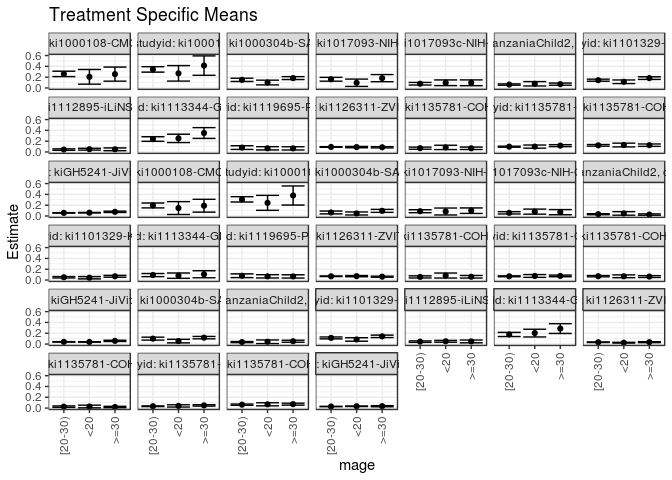

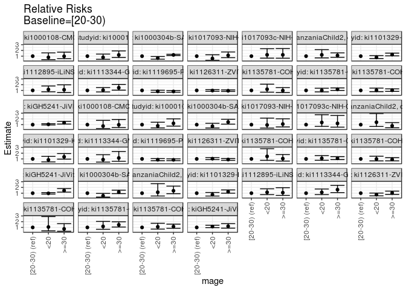

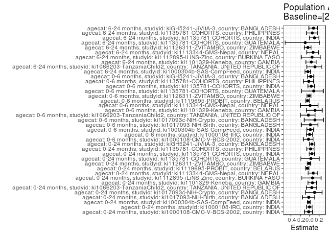

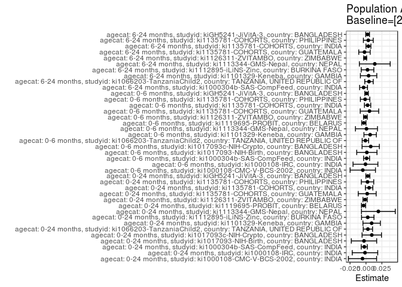

## Results Table

### Parameter: TSM

| agecat | studyid | country | intervention_level | baseline_level | estimate | ci_lower | ci_upper |
| --- | --- | --- | --- | --- | --- | --- | --- |
| 0-24 months | ki1000108-CMC-V-BCS-2002 | INDIA | [20-30) | NA | 0.2601351 | 0.2100901 | 0.3101802 |
| 0-24 months | ki1000108-CMC-V-BCS-2002 | INDIA | <20 | NA | 0.2058824 | 0.0697869 | 0.3419778 |
| 0-24 months | ki1000108-CMC-V-BCS-2002 | INDIA | >=30 | NA | 0.2558140 | 0.1252270 | 0.3864009 |
| 0-24 months | ki1000108-IRC | INDIA | [20-30) | NA | 0.3430233 | 0.2927964 | 0.3932501 |
| 0-24 months | ki1000108-IRC | INDIA | <20 | NA | 0.2702703 | 0.1269995 | 0.4135411 |
| 0-24 months | ki1000108-IRC | INDIA | >=30 | NA | 0.4137931 | 0.2343212 | 0.5932650 |
| 0-24 months | ki1000304b-SAS-CompFeed | INDIA | [20-30) | NA | 0.1500431 | 0.1201652 | 0.1799210 |
| 0-24 months | ki1000304b-SAS-CompFeed | INDIA | <20 | NA | 0.1002234 | 0.0567526 | 0.1436943 |
| 0-24 months | ki1000304b-SAS-CompFeed | INDIA | >=30 | NA | 0.1825615 | 0.1559358 | 0.2091872 |
| 0-24 months | ki1017093-NIH-Birth | BANGLADESH | [20-30) | NA | 0.1606715 | 0.1253966 | 0.1959463 |
| 0-24 months | ki1017093-NIH-Birth | BANGLADESH | <20 | NA | 0.0958904 | 0.0282924 | 0.1634885 |
| 0-24 months | ki1017093-NIH-Birth | BANGLADESH | >=30 | NA | 0.1818182 | 0.1159684 | 0.2476679 |
| 0-24 months | ki1017093c-NIH-Crypto | BANGLADESH | [20-30) | NA | 0.0779382 | 0.0540947 | 0.1017818 |
| 0-24 months | ki1017093c-NIH-Crypto | BANGLADESH | <20 | NA | 0.0959921 | 0.0435669 | 0.1484173 |
| 0-24 months | ki1017093c-NIH-Crypto | BANGLADESH | >=30 | NA | 0.0957445 | 0.0423263 | 0.1491626 |
| 0-24 months | ki1066203-TanzaniaChild2 | TANZANIA, UNITED REPUBLIC OF | [20-30) | NA | 0.0630537 | 0.0510158 | 0.0750916 |
| 0-24 months | ki1066203-TanzaniaChild2 | TANZANIA, UNITED REPUBLIC OF | <20 | NA | 0.0771297 | 0.0367128 | 0.1175466 |
| 0-24 months | ki1066203-TanzaniaChild2 | TANZANIA, UNITED REPUBLIC OF | >=30 | NA | 0.0706144 | 0.0507338 | 0.0904949 |
| 0-24 months | ki1101329-Keneba | GAMBIA | [20-30) | NA | 0.1437066 | 0.1249829 | 0.1624304 |
| 0-24 months | ki1101329-Keneba | GAMBIA | <20 | NA | 0.1147479 | 0.0814602 | 0.1480357 |
| 0-24 months | ki1101329-Keneba | GAMBIA | >=30 | NA | 0.1823831 | 0.1581447 | 0.2066214 |
| 0-24 months | ki1112895-iLiNS-Zinc | BURKINA FASO | [20-30) | NA | 0.0444012 | 0.0310972 | 0.0577052 |
| 0-24 months | ki1112895-iLiNS-Zinc | BURKINA FASO | <20 | NA | 0.0514358 | 0.0345090 | 0.0683627 |
| 0-24 months | ki1112895-iLiNS-Zinc | BURKINA FASO | >=30 | NA | 0.0495907 | 0.0241813 | 0.0750002 |
| 0-24 months | ki1113344-GMS-Nepal | NEPAL | [20-30) | NA | 0.2396574 | 0.1970652 | 0.2822496 |
| 0-24 months | ki1113344-GMS-Nepal | NEPAL | <20 | NA | 0.2517156 | 0.1742948 | 0.3291365 |
| 0-24 months | ki1113344-GMS-Nepal | NEPAL | >=30 | NA | 0.3507894 | 0.2513663 | 0.4502125 |
| 0-24 months | ki1119695-PROBIT | BELARUS | [20-30) | NA | 0.0813284 | 0.0469789 | 0.1156779 |
| 0-24 months | ki1119695-PROBIT | BELARUS | <20 | NA | 0.0680468 | 0.0379801 | 0.0981135 |
| 0-24 months | ki1119695-PROBIT | BELARUS | >=30 | NA | 0.0668743 | 0.0370993 | 0.0966494 |

[output cut: 87 more lines]

### Parameter: E(Y)

| agecat | studyid | country | intervention_level | baseline_level | estimate | ci_lower | ci_upper |
| --- | --- | --- | --- | --- | --- | --- | --- |
| 0-24 months | ki1000108-CMC-V-BCS-2002 | INDIA | NA | NA | 0.2546917 | 0.2104174 | 0.2989660 |
| 0-24 months | ki1000108-IRC | INDIA | NA | NA | 0.3414634 | 0.2955068 | 0.3874201 |
| 0-24 months | ki1000304b-SAS-CompFeed | INDIA | NA | NA | 0.1473893 | 0.1184132 | 0.1763654 |
| 0-24 months | ki1017093-NIH-Birth | BANGLADESH | NA | NA | 0.1575563 | 0.1289019 | 0.1862106 |
| 0-24 months | ki1017093c-NIH-Crypto | BANGLADESH | NA | NA | 0.0870712 | 0.0669870 | 0.1071555 |
| 0-24 months | ki1066203-TanzaniaChild2 | TANZANIA, UNITED REPUBLIC OF | NA | NA | 0.0660774 | 0.0560867 | 0.0760682 |
| 0-24 months | ki1101329-Keneba | GAMBIA | NA | NA | 0.1526371 | 0.1394613 | 0.1658129 |
| 0-24 months | ki1112895-iLiNS-Zinc | BURKINA FASO | NA | NA | 0.0471995 | 0.0353423 | 0.0590567 |
| 0-24 months | ki1113344-GMS-Nepal | NEPAL | NA | NA | 0.2591362 | 0.2241059 | 0.2941665 |
| 0-24 months | ki1119695-PROBIT | BELARUS | NA | NA | 0.0774648 | 0.0450418 | 0.1098878 |
| 0-24 months | ki1126311-ZVITAMBO | ZIMBABWE | NA | NA | 0.0912884 | 0.0865003 | 0.0960765 |
| 0-24 months | ki1135781-COHORTS | GUATEMALA | NA | NA | 0.0723341 | 0.0584645 | 0.0862036 |
| 0-24 months | ki1135781-COHORTS | INDIA | NA | NA | 0.1031103 | 0.0949263 | 0.1112943 |
| 0-24 months | ki1135781-COHORTS | PHILIPPINES | NA | NA | 0.1254516 | 0.1136848 | 0.1372183 |
| 0-24 months | kiGH5241-JiVitA-3 | BANGLADESH | NA | NA | 0.0609299 | 0.0574570 | 0.0644028 |
| 0-6 months | ki1000108-CMC-V-BCS-2002 | INDIA | NA | NA | 0.1902174 | 0.1500638 | 0.2303710 |
| 0-6 months | ki1000108-IRC | INDIA | NA | NA | 0.3073171 | 0.2626027 | 0.3520314 |
| 0-6 months | ki1000304b-SAS-CompFeed | INDIA | NA | NA | 0.0664452 | 0.0425975 | 0.0902929 |
| 0-6 months | ki1017093-NIH-Birth | BANGLADESH | NA | NA | 0.0903226 | 0.0677415 | 0.1129037 |
| 0-6 months | ki1017093c-NIH-Crypto | BANGLADESH | NA | NA | 0.0659631 | 0.0482810 | 0.0836451 |
| 0-6 months | ki1066203-TanzaniaChild2 | TANZANIA, UNITED REPUBLIC OF | NA | NA | 0.0328283 | 0.0256620 | 0.0399945 |
| 0-6 months | ki1101329-Keneba | GAMBIA | NA | NA | 0.0575569 | 0.0482661 | 0.0668478 |
| 0-6 months | ki1113344-GMS-Nepal | NEPAL | NA | NA | 0.0930233 | 0.0698010 | 0.1162455 |
| 0-6 months | ki1119695-PROBIT | BELARUS | NA | NA | 0.0760580 | 0.0435003 | 0.1086157 |
| 0-6 months | ki1126311-ZVITAMBO | ZIMBABWE | NA | NA | 0.0684336 | 0.0642223 | 0.0726450 |
| 0-6 months | ki1135781-COHORTS | GUATEMALA | NA | NA | 0.0630292 | 0.0484135 | 0.0776449 |
| 0-6 months | ki1135781-COHORTS | INDIA | NA | NA | 0.0713446 | 0.0642809 | 0.0784082 |
| 0-6 months | ki1135781-COHORTS | PHILIPPINES | NA | NA | 0.0693167 | 0.0602923 | 0.0783411 |
| 0-6 months | kiGH5241-JiVitA-3 | BANGLADESH | NA | NA | 0.0413005 | 0.0383253 | 0.0442756 |
| 6-24 months | ki1000304b-SAS-CompFeed | INDIA | NA | NA | 0.0964723 | 0.0729872 | 0.1199573 |
| 6-24 months | ki1066203-TanzaniaChild2 | TANZANIA, UNITED REPUBLIC OF | NA | NA | 0.0414378 | 0.0327076 | 0.0501681 |
| 6-24 months | ki1101329-Keneba | GAMBIA | NA | NA | 0.1178877 | 0.1056970 | 0.1300784 |
| 6-24 months | ki1112895-iLiNS-Zinc | BURKINA FASO | NA | NA | 0.0471995 | 0.0353423 | 0.0590567 |
| 6-24 months | ki1113344-GMS-Nepal | NEPAL | NA | NA | 0.1915254 | 0.1597467 | 0.2233042 |
| 6-24 months | ki1126311-ZVITAMBO | ZIMBABWE | NA | NA | 0.0325272 | 0.0291608 | 0.0358936 |
| 6-24 months | ki1135781-COHORTS | GUATEMALA | NA | NA | 0.0247321 | 0.0159885 | 0.0334756 |
| 6-24 months | ki1135781-COHORTS | INDIA | NA | NA | 0.0381279 | 0.0327962 | 0.0434596 |
| 6-24 months | ki1135781-COHORTS | PHILIPPINES | NA | NA | 0.0669277 | 0.0576848 | 0.0761707 |
| 6-24 months | kiGH5241-JiVitA-3 | BANGLADESH | NA | NA | 0.0319223 | 0.0290352 | 0.0348093 |

### Parameter: RR

| agecat | studyid | country | intervention_level | baseline_level | estimate | ci_lower | ci_upper |
| --- | --- | --- | --- | --- | --- | --- | --- |
| 0-24 months | ki1000108-CMC-V-BCS-2002 | INDIA | [20-30) | [20-30) | 1.0000000 | 1.0000000 | 1.0000000 |
| 0-24 months | ki1000108-CMC-V-BCS-2002 | INDIA | <20 | [20-30) | 0.7914439 | 0.3975810 | 1.5754863 |
| 0-24 months | ki1000108-CMC-V-BCS-2002 | INDIA | >=30 | [20-30) | 0.9833887 | 0.5699112 | 1.6968491 |
| 0-24 months | ki1000108-IRC | INDIA | [20-30) | [20-30) | 1.0000000 | 1.0000000 | 1.0000000 |
| 0-24 months | ki1000108-IRC | INDIA | <20 | [20-30) | 0.7879066 | 0.4546040 | 1.3655769 |
| 0-24 months | ki1000108-IRC | INDIA | >=30 | [20-30) | 1.2063121 | 0.7632228 | 1.9066372 |
| 0-24 months | ki1000304b-SAS-CompFeed | INDIA | [20-30) | [20-30) | 1.0000000 | 1.0000000 | 1.0000000 |
| 0-24 months | ki1000304b-SAS-CompFeed | INDIA | <20 | [20-30) | 0.6679644 | 0.4724568 | 0.9443751 |
| 0-24 months | ki1000304b-SAS-CompFeed | INDIA | >=30 | [20-30) | 1.2167268 | 1.1148178 | 1.3279517 |
| 0-24 months | ki1017093-NIH-Birth | BANGLADESH | [20-30) | [20-30) | 1.0000000 | 1.0000000 | 1.0000000 |
| 0-24 months | ki1017093-NIH-Birth | BANGLADESH | <20 | [20-30) | 0.5968105 | 0.2852176 | 1.2488106 |
| 0-24 months | ki1017093-NIH-Birth | BANGLADESH | >=30 | [20-30) | 1.1316147 | 0.7409103 | 1.7283493 |
| 0-24 months | ki1017093c-NIH-Crypto | BANGLADESH | [20-30) | [20-30) | 1.0000000 | 1.0000000 | 1.0000000 |
| 0-24 months | ki1017093c-NIH-Crypto | BANGLADESH | <20 | [20-30) | 1.2316435 | 0.6588266 | 2.3024964 |
| 0-24 months | ki1017093c-NIH-Crypto | BANGLADESH | >=30 | [20-30) | 1.2284661 | 0.6500199 | 2.3216656 |
| 0-24 months | ki1066203-TanzaniaChild2 | TANZANIA, UNITED REPUBLIC OF | [20-30) | [20-30) | 1.0000000 | 1.0000000 | 1.0000000 |
| 0-24 months | ki1066203-TanzaniaChild2 | TANZANIA, UNITED REPUBLIC OF | <20 | [20-30) | 1.2232389 | 0.7003236 | 2.1366028 |
| 0-24 months | ki1066203-TanzaniaChild2 | TANZANIA, UNITED REPUBLIC OF | >=30 | [20-30) | 1.1199090 | 0.7969705 | 1.5737045 |
| 0-24 months | ki1101329-Keneba | GAMBIA | [20-30) | [20-30) | 1.0000000 | 1.0000000 | 1.0000000 |
| 0-24 months | ki1101329-Keneba | GAMBIA | <20 | [20-30) | 0.7984873 | 0.5810179 | 1.0973535 |
| 0-24 months | ki1101329-Keneba | GAMBIA | >=30 | [20-30) | 1.2691346 | 1.0536994 | 1.5286168 |
| 0-24 months | ki1112895-iLiNS-Zinc | BURKINA FASO | [20-30) | [20-30) | 1.0000000 | 1.0000000 | 1.0000000 |
| 0-24 months | ki1112895-iLiNS-Zinc | BURKINA FASO | <20 | [20-30) | 1.1584338 | 0.7587258 | 1.7687139 |
| 0-24 months | ki1112895-iLiNS-Zinc | BURKINA FASO | >=30 | [20-30) | 1.1168783 | 0.6324621 | 1.9723193 |
| 0-24 months | ki1113344-GMS-Nepal | NEPAL | [20-30) | [20-30) | 1.0000000 | 1.0000000 | 1.0000000 |
| 0-24 months | ki1113344-GMS-Nepal | NEPAL | <20 | [20-30) | 1.0503147 | 0.7363018 | 1.4982456 |
| 0-24 months | ki1113344-GMS-Nepal | NEPAL | >=30 | [20-30) | 1.4637122 | 1.0476224 | 2.0450625 |
| 0-24 months | ki1119695-PROBIT | BELARUS | [20-30) | [20-30) | 1.0000000 | 1.0000000 | 1.0000000 |
| 0-24 months | ki1119695-PROBIT | BELARUS | <20 | [20-30) | 0.8366920 | 0.6802400 | 1.0291273 |
| 0-24 months | ki1119695-PROBIT | BELARUS | >=30 | [20-30) | 0.8222751 | 0.6859547 | 0.9856867 |

[output cut: 87 more lines]

### Parameter: PAR

| agecat | studyid | country | intervention_level | baseline_level | estimate | ci_lower | ci_upper |
| --- | --- | --- | --- | --- | --- | --- | --- |
| 0-24 months | ki1000108-CMC-V-BCS-2002 | INDIA | [20-30) | NA | -0.0054434 | -0.0275736 | 0.0166867 |
| 0-24 months | ki1000108-IRC | INDIA | [20-30) | NA | -0.0015598 | -0.0215967 | 0.0184770 |
| 0-24 months | ki1000304b-SAS-CompFeed | INDIA | [20-30) | NA | -0.0026538 | -0.0074350 | 0.0021274 |
| 0-24 months | ki1017093-NIH-Birth | BANGLADESH | [20-30) | NA | -0.0031152 | -0.0230392 | 0.0168088 |
| 0-24 months | ki1017093c-NIH-Crypto | BANGLADESH | [20-30) | NA | 0.0091330 | -0.0061286 | 0.0243946 |
| 0-24 months | ki1066203-TanzaniaChild2 | TANZANIA, UNITED REPUBLIC OF | [20-30) | NA | 0.0030238 | -0.0042858 | 0.0103333 |
| 0-24 months | ki1101329-Keneba | GAMBIA | [20-30) | NA | 0.0089304 | -0.0047947 | 0.0226556 |
| 0-24 months | ki1112895-iLiNS-Zinc | BURKINA FASO | [20-30) | NA | 0.0027983 | -0.0069818 | 0.0125784 |
| 0-24 months | ki1113344-GMS-Nepal | NEPAL | [20-30) | NA | 0.0194789 | -0.0071043 | 0.0460620 |
| 0-24 months | ki1119695-PROBIT | BELARUS | [20-30) | NA | -0.0038636 | -0.0071278 | -0.0005995 |
| 0-24 months | ki1126311-ZVITAMBO | ZIMBABWE | [20-30) | NA | -0.0013956 | -0.0047524 | 0.0019612 |
| 0-24 months | ki1135781-COHORTS | GUATEMALA | [20-30) | NA | 0.0019379 | -0.0121431 | 0.0160189 |
| 0-24 months | ki1135781-COHORTS | INDIA | [20-30) | NA | 0.0049204 | -0.0009143 | 0.0107550 |
| 0-24 months | ki1135781-COHORTS | PHILIPPINES | [20-30) | NA | 0.0024304 | -0.0073141 | 0.0121750 |
| 0-24 months | kiGH5241-JiVitA-3 | BANGLADESH | [20-30) | NA | 0.0029629 | -0.0002288 | 0.0061546 |
| 0-6 months | ki1000108-CMC-V-BCS-2002 | INDIA | [20-30) | NA | -0.0049881 | -0.0248855 | 0.0149093 |
| 0-6 months | ki1000108-IRC | INDIA | [20-30) | NA | -0.0008225 | -0.0203468 | 0.0187019 |
| 0-6 months | ki1000304b-SAS-CompFeed | INDIA | [20-30) | NA | 0.0010002 | -0.0036966 | 0.0056969 |
| 0-6 months | ki1017093-NIH-Birth | BANGLADESH | [20-30) | NA | 0.0013803 | -0.0145456 | 0.0173061 |
| 0-6 months | ki1017093c-NIH-Crypto | BANGLADESH | [20-30) | NA | 0.0074413 | -0.0061418 | 0.0210244 |
| 0-6 months | ki1066203-TanzaniaChild2 | TANZANIA, UNITED REPUBLIC OF | [20-30) | NA | -0.0009082 | -0.0059724 | 0.0041560 |
| 0-6 months | ki1101329-Keneba | GAMBIA | [20-30) | NA | 0.0065579 | -0.0031817 | 0.0162975 |
| 0-6 months | ki1113344-GMS-Nepal | NEPAL | [20-30) | NA | 0.0007738 | -0.0165659 | 0.0181134 |
| 0-6 months | ki1119695-PROBIT | BELARUS | [20-30) | NA | -0.0033649 | -0.0067056 | -0.0000241 |
| 0-6 months | ki1126311-ZVITAMBO | ZIMBABWE | [20-30) | NA | -0.0008874 | -0.0038356 | 0.0020607 |
| 0-6 months | ki1135781-COHORTS | GUATEMALA | [20-30) | NA | 0.0054890 | -0.0090317 | 0.0200097 |
| 0-6 months | ki1135781-COHORTS | INDIA | [20-30) | NA | 0.0025208 | -0.0024440 | 0.0074856 |
| 0-6 months | ki1135781-COHORTS | PHILIPPINES | [20-30) | NA | -0.0013619 | -0.0087809 | 0.0060571 |
| 0-6 months | kiGH5241-JiVitA-3 | BANGLADESH | [20-30) | NA | 0.0009288 | -0.0018505 | 0.0037080 |
| 6-24 months | ki1000304b-SAS-CompFeed | INDIA | [20-30) | NA | -0.0037835 | -0.0099705 | 0.0024036 |
| 6-24 months | ki1066203-TanzaniaChild2 | TANZANIA, UNITED REPUBLIC OF | [20-30) | NA | 0.0047125 | -0.0019571 | 0.0113821 |
| 6-24 months | ki1101329-Keneba | GAMBIA | [20-30) | NA | 0.0041163 | -0.0087674 | 0.0170001 |
| 6-24 months | ki1112895-iLiNS-Zinc | BURKINA FASO | [20-30) | NA | 0.0024334 | -0.0074770 | 0.0123437 |
| 6-24 months | ki1113344-GMS-Nepal | NEPAL | [20-30) | NA | 0.0138623 | -0.0103432 | 0.0380678 |
| 6-24 months | ki1126311-ZVITAMBO | ZIMBABWE | [20-30) | NA | -0.0012778 | -0.0036235 | 0.0010679 |
| 6-24 months | ki1135781-COHORTS | GUATEMALA | [20-30) | NA | -0.0023407 | -0.0113312 | 0.0066498 |
| 6-24 months | ki1135781-COHORTS | INDIA | [20-30) | NA | 0.0038521 | -0.0000408 | 0.0077450 |
| 6-24 months | ki1135781-COHORTS | PHILIPPINES | [20-30) | NA | 0.0036714 | -0.0040643 | 0.0114071 |
| 6-24 months | kiGH5241-JiVitA-3 | BANGLADESH | [20-30) | NA | 0.0025693 | -0.0004058 | 0.0055443 |

### Parameter: PAF

| agecat | studyid | country | intervention_level | baseline_level | estimate | ci_lower | ci_upper |
| --- | --- | --- | --- | --- | --- | --- | --- |
| 0-24 months | ki1000108-CMC-V-BCS-2002 | INDIA | [20-30) | NA | -0.0213727 | -0.1120395 | 0.0619019 |
| 0-24 months | ki1000108-IRC | INDIA | [20-30) | NA | -0.0045681 | -0.0649954 | 0.0524305 |
| 0-24 months | ki1000304b-SAS-CompFeed | INDIA | [20-30) | NA | -0.0180054 | -0.0507677 | 0.0137353 |
| 0-24 months | ki1017093-NIH-Birth | BANGLADESH | [20-30) | NA | -0.0197719 | -0.1543674 | 0.0991301 |
| 0-24 months | ki1017093c-NIH-Crypto | BANGLADESH | [20-30) | NA | 0.1048914 | -0.0874989 | 0.2632458 |
| 0-24 months | ki1066203-TanzaniaChild2 | TANZANIA, UNITED REPUBLIC OF | [20-30) | NA | 0.0457609 | -0.0713271 | 0.1500521 |
| 0-24 months | ki1101329-Keneba | GAMBIA | [20-30) | NA | 0.0585077 | -0.0358272 | 0.1442514 |
| 0-24 months | ki1112895-iLiNS-Zinc | BURKINA FASO | [20-30) | NA | 0.0592867 | -0.1684136 | 0.2426127 |
| 0-24 months | ki1113344-GMS-Nepal | NEPAL | [20-30) | NA | 0.0751684 | -0.0331534 | 0.1721331 |
| 0-24 months | ki1119695-PROBIT | BELARUS | [20-30) | NA | -0.0498760 | -0.0855509 | -0.0153735 |
| 0-24 months | ki1126311-ZVITAMBO | ZIMBABWE | [20-30) | NA | -0.0152877 | -0.0527235 | 0.0208168 |
| 0-24 months | ki1135781-COHORTS | GUATEMALA | [20-30) | NA | 0.0267910 | -0.1886563 | 0.2031878 |
| 0-24 months | ki1135781-COHORTS | INDIA | [20-30) | NA | 0.0477193 | -0.0104802 | 0.1025668 |
| 0-24 months | ki1135781-COHORTS | PHILIPPINES | [20-30) | NA | 0.0193735 | -0.0614496 | 0.0940424 |
| 0-24 months | kiGH5241-JiVitA-3 | BANGLADESH | [20-30) | NA | 0.0486286 | -0.0051788 | 0.0995557 |
| 0-6 months | ki1000108-CMC-V-BCS-2002 | INDIA | [20-30) | NA | -0.0262231 | -0.1362595 | 0.0731573 |
| 0-6 months | ki1000108-IRC | INDIA | [20-30) | NA | -0.0026763 | -0.0682637 | 0.0588843 |
| 0-6 months | ki1000304b-SAS-CompFeed | INDIA | [20-30) | NA | 0.0150524 | -0.0603904 | 0.0851277 |
| 0-6 months | ki1017093-NIH-Birth | BANGLADESH | [20-30) | NA | 0.0152816 | -0.1777722 | 0.1766911 |
| 0-6 months | ki1017093c-NIH-Crypto | BANGLADESH | [20-30) | NA | 0.1128103 | -0.1167558 | 0.2951857 |
| 0-6 months | ki1066203-TanzaniaChild2 | TANZANIA, UNITED REPUBLIC OF | [20-30) | NA | -0.0276649 | -0.1939816 | 0.1154846 |
| 0-6 months | ki1101329-Keneba | GAMBIA | [20-30) | NA | 0.1139376 | -0.0715049 | 0.2672860 |
| 0-6 months | ki1113344-GMS-Nepal | NEPAL | [20-30) | NA | 0.0083181 | -0.1967646 | 0.1782569 |
| 0-6 months | ki1119695-PROBIT | BELARUS | [20-30) | NA | -0.0442406 | -0.0818914 | -0.0079001 |
| 0-6 months | ki1126311-ZVITAMBO | ZIMBABWE | [20-30) | NA | -0.0129674 | -0.0569686 | 0.0292020 |
| 0-6 months | ki1135781-COHORTS | GUATEMALA | [20-30) | NA | 0.0870861 | -0.1738964 | 0.2900465 |
| 0-6 months | ki1135781-COHORTS | INDIA | [20-30) | NA | 0.0353331 | -0.0367561 | 0.1024097 |
| 0-6 months | ki1135781-COHORTS | PHILIPPINES | [20-30) | NA | -0.0196481 | -0.1324667 | 0.0819314 |
| 0-6 months | kiGH5241-JiVitA-3 | BANGLADESH | [20-30) | NA | 0.0224881 | -0.0471774 | 0.0875189 |
| 6-24 months | ki1000304b-SAS-CompFeed | INDIA | [20-30) | NA | -0.0392182 | -0.1003608 | 0.0185270 |
| 6-24 months | ki1066203-TanzaniaChild2 | TANZANIA, UNITED REPUBLIC OF | [20-30) | NA | 0.1137250 | -0.0607877 | 0.2595282 |
| 6-24 months | ki1101329-Keneba | GAMBIA | [20-30) | NA | 0.0349172 | -0.0808031 | 0.1382475 |
| 6-24 months | ki1112895-iLiNS-Zinc | BURKINA FASO | [20-30) | NA | 0.0515553 | -0.1798726 | 0.2375894 |
| 6-24 months | ki1113344-GMS-Nepal | NEPAL | [20-30) | NA | 0.0723783 | -0.0625138 | 0.1901451 |
| 6-24 months | ki1126311-ZVITAMBO | ZIMBABWE | [20-30) | NA | -0.0392847 | -0.1138399 | 0.0302801 |
| 6-24 months | ki1135781-COHORTS | GUATEMALA | [20-30) | NA | -0.0946418 | -0.5237626 | 0.2136303 |
| 6-24 months | ki1135781-COHORTS | INDIA | [20-30) | NA | 0.1010312 | -0.0061060 | 0.1967596 |
| 6-24 months | ki1135781-COHORTS | PHILIPPINES | [20-30) | NA | 0.0548563 | -0.0678843 | 0.1634893 |
| 6-24 months | kiGH5241-JiVitA-3 | BANGLADESH | [20-30) | NA | 0.0804855 | -0.0172537 | 0.1688337 |